# Reproducible Research Project 1

Rafael Gurgel

30 dezembro, 2017

## Introduction

This is the Course Project 1 of the *Reproducible Research* course. It analysis a provided data from a personal activity monitoring device during the months of October and November, 2012.

### Reading and processing the data

The data is provided in a *.zip* format. It was uncompressed getting the *activity.csv* file included on [this current GitHub repository](https://github.com/rafagurgel/RepData_PeerAssessment1).

```r
data<-read.table("activity.csv", header=T, sep=",")
data<-transform(data,date=as.Date(date))
data.byday<- data %>%
    group_by(date) %>%
    summarise(Steps.Total = sum(steps)) %>%
    select(Date = date, Steps.Total)

data.bymin<- data %>%
    group_by(interval)%>%
    summarise(Steps.Mean = mean(steps, na.rm = TRUE))%>%
    select(Interval = interval, Steps.Mean)
```

### What is mean total number of steps taken per day?

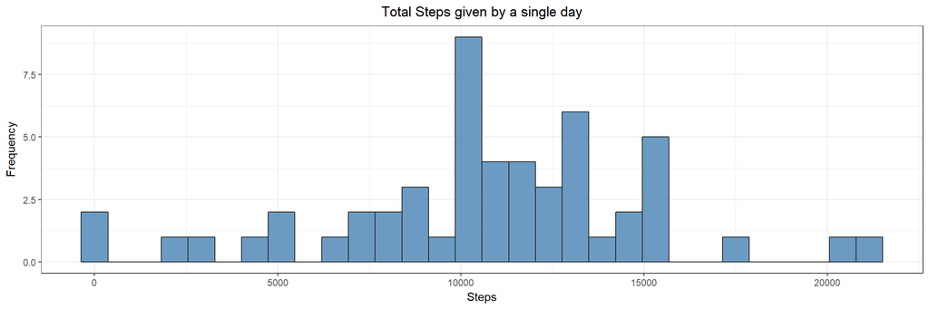

```r
g<- ggplot(data.byday, aes(Steps.Total),na.rm=TRUE)
g + geom_histogram(color="#222222",fill="steelblue", alpha=0.8) +
    theme_bw() +
    labs(title="Total Steps given by a single day",x ="Steps", y = "Frequency") +
    theme(plot.title = element_text(hjust = 0.5))
```

```r
# Save figure
tmp <- dev.copy(png,'figure/histogram_01.png')
tmp <- dev.off()

# Mean daily steps
steps.mean <- mean(data.byday$Steps.Total,na.rm=TRUE)
# Median daily steps
steps.median <- median(data.byday$Steps.Total,na.rm=TRUE)
```

The mean of daily steps is **10766.19** and the median is **10765**.

### What is the average daily activity pattern?

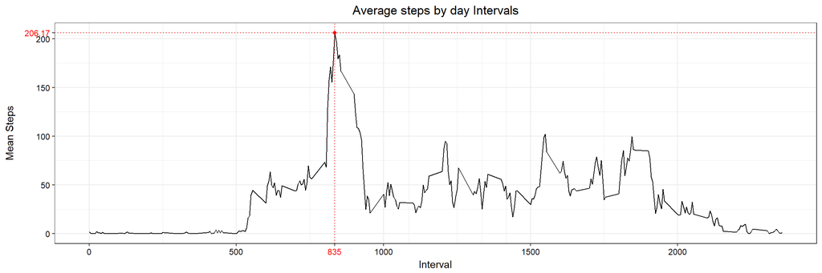

```r
# Get the max point in dataframe
max.interval<- data.bymin%>%filter(Steps.Mean == max(Steps.Mean))
g<- ggplot(data.bymin, aes(Interval,Steps.Mean),na.rm=TRUE)
g + geom_line() +
    theme_bw() +
    scale_y_continuous(breaks = c(0,50,100,150,200,max.interval$Steps.Mean), labels=c(0,50,100,150,200,sprintf("  %.2f",max.interval$Steps.Mean)   )) +
    scale_x_continuous(breaks = c(0,500,1000,1500,2000,max.interval$Interval), labels=c(0,500,1000,1500,2000,max.interval$Interval)) +
    theme(axis.text.y = element_text(colour = c('black', 'black', 'black', 'black', 'black', 'red' )), axis.text.x = element_text(colour = c('black', 'black', 'black', 'black', 'black', 'red' ))) +
    geom_vline(xintercept = max.interval$Interval, 'col' = 'red', linetype='dotted') +
    geom_hline(yintercept = max.interval$Steps.Mean, 'col' = 'red',linetype='dotted') +
    geom_point(aes(max.interval$Interval, max.interval$Steps.Mean), col='red') +
    labs(title="Average steps by day Intervals",x ="Interval", y = "Mean Steps") +
    theme(plot.title = element_text(hjust = 0.5))
```

```r
# Save figure
tmp <- dev.copy(png,'figure/timeseries_01.png')
tmp <- dev.off()
```

As we can see, the user has achieved the biggest average steps of **206.1698** when has passed **835** minutes.

### Inputing missing values

```r
nna <- with(data,sum(is.na(steps)))
```

There are **2304** missing values coded as NA. These values will be replaced by the median of the 5-minute interval.

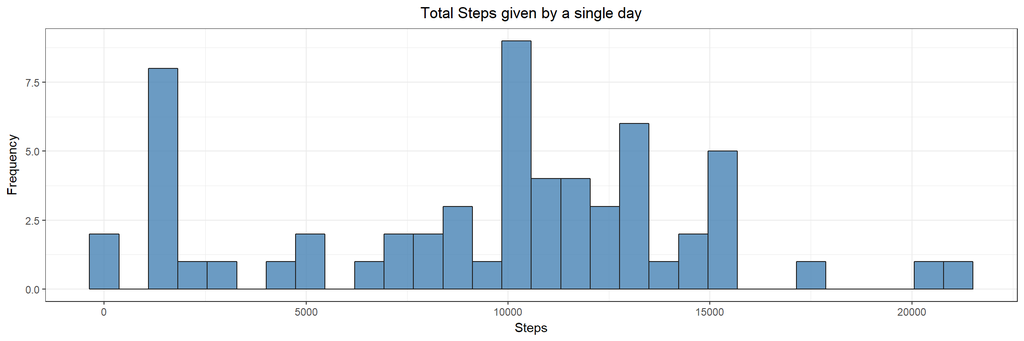

```r
# Get the median by interval
data.bymin.median<- data %>%
    group_by(interval)%>%
    summarise(Steps.Median = median(steps, na.rm = TRUE))%>%
    select(Interval = interval, Steps.Median)

data.byday2 <- data %>%
    mutate(Steps= ifelse(is.na(steps),data.bymin.median$Steps.Median, steps))%>%
    group_by(date) %>%
    summarise(Steps.Total = sum(Steps)) %>%
    select(Date = date, Steps.Total)

data.bymin2<- data %>%
    mutate(Steps= ifelse(is.na(steps),data.bymin.median$Steps.Median, steps))%>%
    group_by(interval)%>%
    summarise(Steps.Mean = mean(steps, na.rm = TRUE))%>%
    select(Interval = interval, Steps.Mean)
# Histogram
g<- ggplot(data.byday2, aes(Steps.Total),na.rm=TRUE)
g + geom_histogram(color="#222222",fill="steelblue", alpha=0.8) +
    theme_bw() +
    labs(title="Total Steps given by a single day",x ="Steps", y = "Frequency") +
    theme(plot.title = element_text(hjust = 0.5))
```

```r
# Save figure
tmp <- dev.copy(png,'figure/histogram_02.png')
tmp <- dev.off()
# Mean daily steps
steps.mean2 <- mean(data.byday2$Steps.Total,na.rm=TRUE)
# Median daily steps
steps.median2 <- median(data.byday2$Steps.Total,na.rm=TRUE)
```

As we can see, the mean and median’s values (**9503.869** and **10395**) differ than the values calculated before (**10766.19** and **10765**). It is expected considerating the filling strategy adopted.

### Are there differences in activity patterns between weekdays and weekends?

First we need to create a new factor variable in the dataset indicating whether a given date is a weekday or weekend day. It wasn’t informed if the data in this analysis will be the original or with the NA’s replacement. I decided to use the original data

```r
data.bymin.weekdays <- data %>%
    group_by(date) %>%
    mutate(Weekday = as.factor(weekdays(date)))%>%
    mutate(Weekday = ifelse((Weekday == "Saturday")||(Weekday == "Sunday"),"Weekend","Weekday"))%>%
    mutate(Weekday = as.factor(Weekday))%>%
    group_by(interval,Weekday)%>%
    summarise(Steps.Mean = mean(steps, na.rm = TRUE))%>%
    select(Interval = interval, Weekday,Steps.Mean)
```

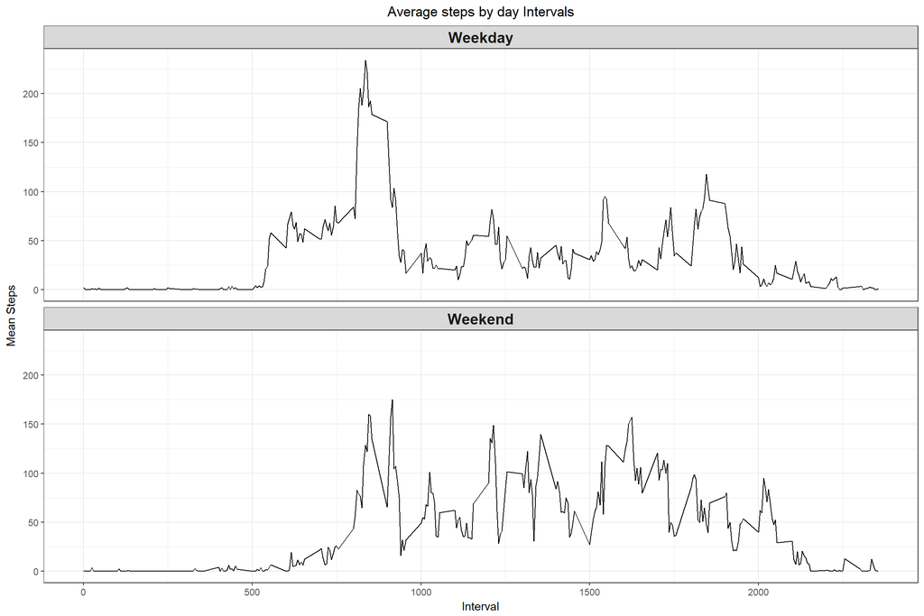

```r
g<- ggplot(data.bymin.weekdays, aes(Interval,Steps.Mean),na.rm=TRUE)
g + geom_line() +
    theme_bw() +
    facet_wrap(~Weekday,ncol = 1) +
    labs(title="Average steps by day Intervals",x ="Interval", y = "Mean Steps") +
    theme(plot.title = element_text(hjust = 0.5),strip.text = element_text(face="bold", size=14))
```

```r
# Save figure
tmp <- dev.copy(png,'figure/timeseries_02.png')
tmp <- dev.off()
```